# Week 5 Lab

4/29/2025

## *Goals:*

1. Visualizing dichotomous outcomes with continuous and categorical explanatory variables,
2. Conduct a basic logistic regression with continuous estimates
3. Conduct a basic logistic regression with categorical estimates

*Instruction to work on this sheet:* In each code chunk, you can find some code being taken out purposely and left with three dots instead. Your task is to first uncomment the code line, replace the three dots with the code you would write, and then run the code to proceed.

*Data* For this lab, we will be using the prinicpal.csv dataset available [here](https://raw.githubusercontent.com/uo-educ-quant/645/master/data/principal.csv). Read in the dataset in the environment and save it to the object prin.

*Brief variable descriptions:*

- *schid*, identifier variable for School ID
- *stuid*, identifier variable for Student ID
- *pfemale*, an indicator variable telling if the school principal is a female or not (1 - is a female, 0 - not a female)
- *page*, age of the principal
- *sfemale*, an indicator variable telling if the student is a female or not (1 - is a female, 0 - not a female)
- *match*, an indicator variable telling if the student and principal self-reported sex matched or not (1 - matched, 0 - didn’t match)
- *attention*, standardized attention score for the student
- *affective*, an indicator variable telling if the student considers the principal to be affective (1 - Yes, - 0 No)

### Topic: Dichotomous outcomes and basic logistic regression

### Packages and Data

```r
# Load necessary packages
library(tidyverse)
#install.packages("broom")
library(broom)
library(modelsummary)

# read in dataset and select variables of interest
# Quotes are important around URL link for data retrieval

prin <- read.csv("https://raw.githubusercontent.com/uo-educ-quant/645/master/data/principal.csv") %>%
  drop_na() #this is a simplistic way of dealing with missing data, we simply drop observations with missingness on any row
```

**RQ1: What is the relationship between principal age *page* and student response of principal affectiveness *affective* (1 - Yes, - 0 No)?**

**Task 1: Prepare your dataset for analysis by selecting the relevant variables, and transforming to factor wherever needed.**

```r
# check that variables are the correct types.
# Dichotomous variables should be factors, and continuous variables should be numeric (num) or integers (int).
# factor all categorical variable


str(prin)
```

```
## 'data.frame':    780 obs. of  8 variables:
##  $ schid    : int  6 6 6 6 6 6 6 6 13 13 ...
##  $ stuid    : int  0 1 2 3 4 5 6 9 0 1 ...
##  $ pfemale  : int  1 1 1 1 1 1 1 1 1 1 ...
##  $ page     : int  38 44 38 40 36 36 40 39 37 39 ...
##  $ sfemale  : int  0 0 0 0 0 0 0 0 0 1 ...
##  $ match    : int  0 0 0 0 0 0 0 0 0 1 ...
##  $ attention: num  0.283 -2.305 0.607 -0.364 0.607 ...
##  $ affective: int  0 1 0 0 0 0 0 0 0 1 ...
```

```r
# convert any dichotomous variable to factor
 prin$pfemale <- factor(prin$pfemale,
                    levels = c(0,1),
                    labels = c("male", "female"))

  prin$sfemale <- factor(prin$sfemale,
                    levels = c(0,1),
                    labels = c("male", "female"))
  prin$affective <- factor(prin$affective,
                           levels = c(0,1),
                           labels = c("Not Affective", "Affective"))

str(prin)
```

```
## 'data.frame':    780 obs. of  8 variables:
##  $ schid    : int  6 6 6 6 6 6 6 6 13 13 ...
##  $ stuid    : int  0 1 2 3 4 5 6 9 0 1 ...
##  $ pfemale  : Factor w/ 2 levels "male","female": 2 2 2 2 2 2 2 2 2 2 ...
##  $ page     : int  38 44 38 40 36 36 40 39 37 39 ...
##  $ sfemale  : Factor w/ 2 levels "male","female": 1 1 1 1 1 1 1 1 1 2 ...
##  $ match    : int  0 0 0 0 0 0 0 0 0 1 ...
##  $ attention: num  0.283 -2.305 0.607 -0.364 0.607 ...
##  $ affective: Factor w/ 2 levels "Not Affective",..: 1 2 1 1 1 1 1 1 1 2 ...
```

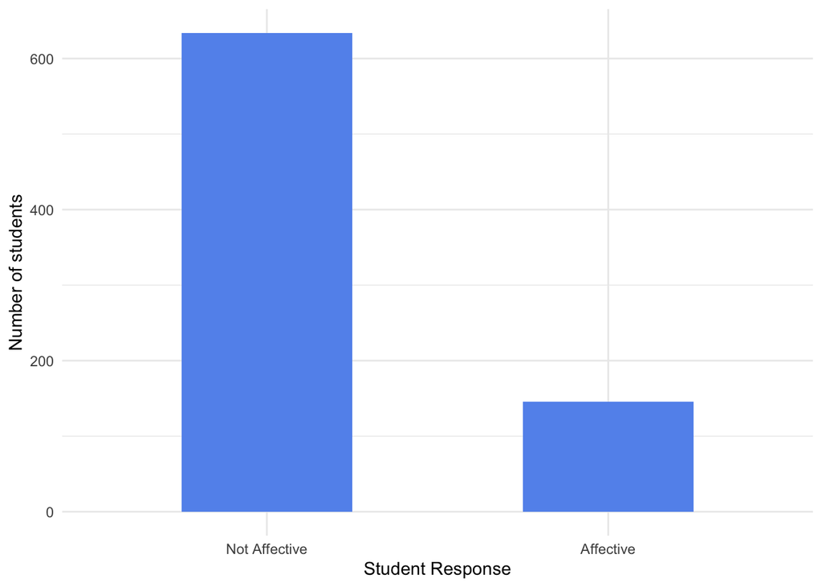

```r
# Some raw data visualization
# The outcome variable
ggplot(prin, aes(x = affective)) +
    geom_bar(fill = "cornflowerblue", width = 0.5)+
    theme_minimal() +
    labs(x = "Student Response",
         y = "Number of students")
```

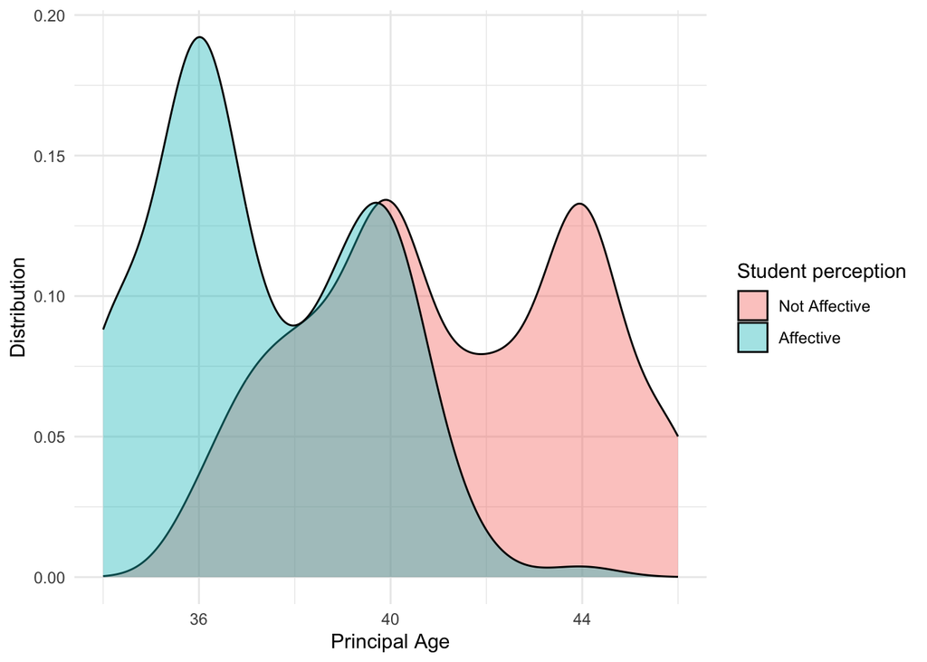

```r
# The outcome and predictor variables
ggplot(prin, aes(x = page, fill = affective)) +
    geom_density(alpha = 0.4)+
    theme_minimal() +
    labs(x = "Principal Age",
         y = "Distribution",
         fill = "Student perception")
```